# QC and filtering

Marta Pérez Alcántara

17 de mayo de 2018

I start the analysis from a file that contains the feature counts per peak and that has the following columns: Geneid, Chr, Start, End, Strand, Length, and each sample & differentiation stage. Check beforehand that the count distribution looks like a negative binomial distribution (variance larger than mean).

## Step 1: exploratory normalization

The initial number of peaks is 181773. The initial normalization of atac-seq data doesn’t have any filtering. Its purpose is to explore the behaviour of the counts and set a cutoff value for posterior filtering. I’ll use edgeR, using TMM normalization, as the distribution of counts per peak (which will be treated as counts per gene, just like in RNA-seq data) is negative binomial (variance much larger than the mean). edgeR also manages better the presence of zero counts than limma+voom. Now I will create the DGE object:

Calculate the normalization factors using TMM:

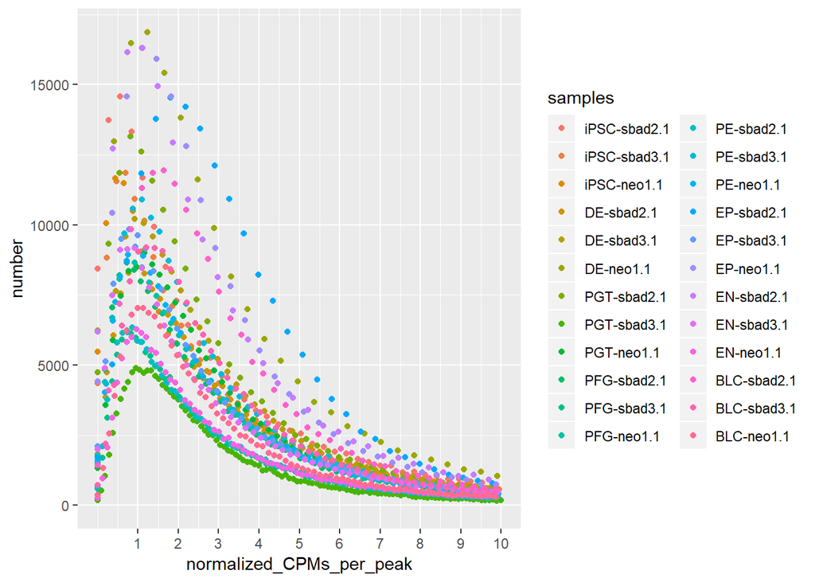

The mean counts for all samples is 5.52. The variance of counts for all samples is 91.51.

## Step 2: exploratory filtering

Plot the distribution of CPM trimming and percentage of peaks that remain from the original amount (from CPM 1 to 7 or so).

```r
# load(file = "/Users/Marta/Documents/WTCHG/DPhil/Data/Regulation/atac-seq/session_objects/dge_atac-seq.xz", verbose = TRUE)  #loading the dge object

old_peaks = dim(dge)[1]# save how many peaks there are initially

remainder_after_trim_by_stage_and_cpm = function(dge,
                                                 CPM = 1,
                                                 old_peaks = dim(dge)[1]) {
  # 1st trim:
  keep <-
    rowSums(cpm(dge, normalized.lib.sizes = TRUE) > CPM) >= 3   # getting peaks with at least n cpm in at least one stage (3 rep per stage).
  dge <-
    dge[keep, , keep.lib.sizes = TRUE]  # removing unwanted peaks

  dge <-
    calcNormFactors(dge)# recalculating normalization factors after altering library sizes
  # if counts are distributed roughly equally across all samples, it should not change much

  # 2nd trim:
  # go through the table 3 by 3
  # if there are more than 2 values in three columns above 0, go to next row.
  # if not, go to next 3
  # if gets to end of loop and not found the values, get that row. After loop, subset matrix excluding those rows

  trim_by_stage = function(dge) {
    data = cpm(dge, normalized.lib.sizes = TRUE)
    data[data < CPM] = 0
    data[data > CPM] = 1 # convert to table where 0=0 and 1 equals any value above n

    c = c() # initiate vector of numbers, to save rows to take out of matrix

    for (r in 1:nrow(data)) {
      for (i in seq(1, 24, 3)) {
        # loop through stages 3 by 3 (to jump over samples of same stage)

        if (sum(data[r, c(i, i + 1, i + 2)]) > 2) {
          break
        }
        if (i == 22) {
          c = c(c, r)  # if it gets to the end and there are no valid values, append to vector
        }


      }

    }

    rm(data)
    return(c)

  }

  c = trim_by_stage(dge)  # calling function above

  fail = 100 * (length(c) / nrow(dge$counts))
  peaks_fail = length(c)
  ditch = dge$counts[c, ] # table to throw away

  keep = !(rownames(dge$counts) %in% rownames(ditch))

  dge <-
    dge[keep, , keep.lib.sizes = FALSE]

  message(paste("The counts object now has ", nrow(dge$counts), " peaks", sep = ""))

  rm(c, keep, ditch)

  peaks_remain = ((nrow(dge) / old_peaks) * 100)

  return(peaks_remain)
}

# call function for all CPMs
peaks_remain = c()
for (i in 1:10) {
  peaks_remain[i] = remainder_after_trim_by_stage_and_cpm(dge, CPM = i, old_peaks =
                                                            dim(dge)[1])
}
```

```
## The counts object now has 179222 peaks
```

```
## The counts object now has 157480 peaks
```

```
## The counts object now has 125611 peaks
```

```
## The counts object now has 99022 peaks
```

```
## The counts object now has 78584 peaks
```

```
## The counts object now has 64707 peaks
```

```
## The counts object now has 53872 peaks
```

```
## The counts object now has 45852 peaks
```

```
## The counts object now has 39584 peaks
```

```
## The counts object now has 34549 peaks
```

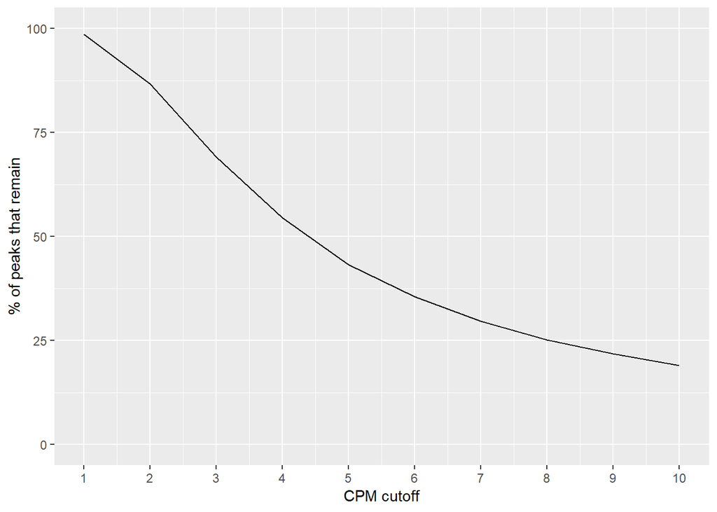

```r
df = data.frame(CPM = c(1:10), peaks_remain = peaks_remain)


p <- ggplot(df, aes(y = peaks_remain, x = CPM)) +
  geom_line() + xlab("CPM cutoff") + ylab("% of peaks that remain") +
  scale_x_continuous(limits = c(1, 10), breaks = c(1:10)) + ylim(c(0, 100))
p
```

```r
# ggsave(  paste(
#     "/Users/Marta/Documents/WTCHG/DPhil/Plots/atac-seq/distribution_counts_per_peak_plotCoverage/CPM_cutoff_peaks_remaining",
#     currentDate,
#     ".jpg",
#     sep = ""
#   ),
#   p,
#   width = 4,
#   height = 4,
#   units = "in",
#   dpi = 300
# )
```

With this plot one should have enough information to chose the right CPM cutoff. A cutoff of 10 CPM is reasonable, as it is difficult to make sense of peaks with less than that amount of counts and will eliminate noise in the posterior WGCNA clustering.

Save dge object after trimming:

```r
# This CPM cut-off might be too stringent
CPM = 10

# # 1st trim:
# keep <-
#   rowSums(cpm(dge, normalized.lib.sizes = TRUE) > CPM) >= 3   # getting peaks with at least n cpm in at least one stage (3 rep per stage).
# dge <-
#   dge[keep, , keep.lib.sizes = TRUE]
#

# 2nd trim:
# go through the table 3 by 3
# if there are more than 2 values in three columns above 0, go to next row.
# if not, go to next 3
# if gets to end of loop and not found the values, get that row. After loop, subset matrix excluding those rows

trim_by_stage = function(dge) {
  data = cpm(dge, normalized.lib.sizes = TRUE)
  data[data < CPM] = 0
  data[data > CPM] = 1 # convert to table where 0=0 and 1 equals any value above n

  c = c() # initiate vector of numbers, to save rows to take out of matrix

  for (r in 1:nrow(data)) {
    for (i in seq(1, 24, 3)) {
      # loop through stages 3 by 3 (to jump over samples of same stage)

      if (sum(data[r, c(i, i + 1, i + 2)]) > 2) {
        break
      }
      if (i == 22) {
        c = c(c, r)  # if it gets to the end and there are no valid values, append to vector
      }


    }

  }

  rm(data)
  return(c)

}

c = trim_by_stage(dge)  # calling function above

ditch = dge$counts[c, ] # table to throw away

keep = !(rownames(dge$counts) %in% rownames(ditch))

dge <-
  dge[keep, , keep.lib.sizes = TRUE]

#keep only autosomal peaks
chr <- as.factor(paste("chr", c(1:22), sep=""))
dge <- dge[which(dge$genes$Chr %in% chr),, keep.lib.sizes = TRUE]

dim(dge)
```

```
## [1] 34910    24
```

```r
save(dge, file = "/Users/Marta/Documents/WTCHG/DPhil/Data/Regulation/atac-seq/session_objects/dge_atac-seq_10CPM_trim.xz" , compress = "xz")   # saving the dge object

# save CPM table so I don't have to re-calculate CPMs on trimmed dge object (and therefore give lower CPMs than there really are!!

CPMs = CPMs[which(rownames(CPMs) %in% dge$genes$Geneid),]
write.table(CPMs, file = "/Users/Marta/Documents/WTCHG/DPhil/Data/Regulation/atac-seq/CPMs_atac-seq_10CPM_trim.txt")
```

Saved dge object has 34910 peaks.